# POLS 1600: Data and Measurement

## Median as rank stastics

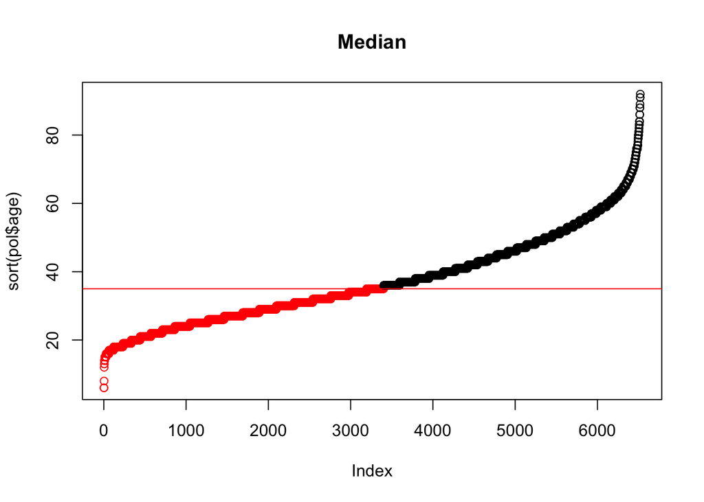

```r
plot(sort(pol$age),col=ifelse(sort(pol$age)<=median(pol$age,na.rm=T),"red","black"),main="Median")
abline(h=median(pol$age,na.rm=T),col="red")
```

## Median as rank stastics

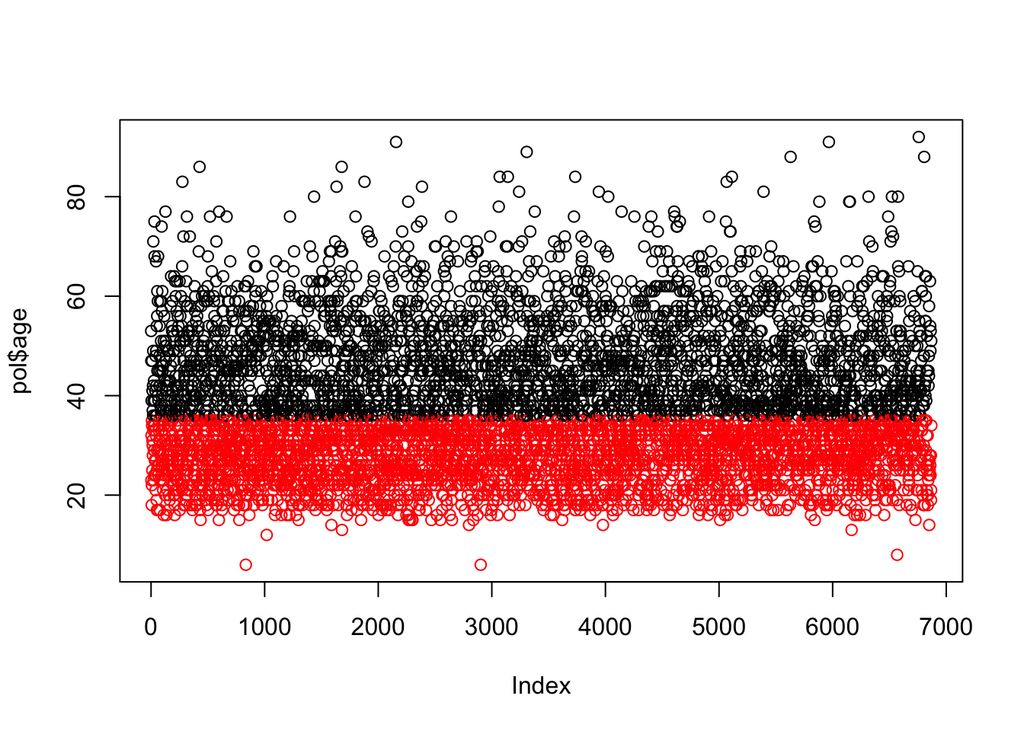

```r
plot(pol$age,col=ifelse(pol$age<=median(pol$age,na.rm=T),"red","black"))
```

## The p-th percentile

$$p_x = X_i : \int_{-\infty}^{x_i} f_x(X)dx= p; \int_{x_i}^\infty f_x(X)dx=1-p$$

- The value of the observation such that 100*p percent of the data are to the left and 100-100*p are two the right.
- The median is just the 50th percentile

## Mode

$$m_x = X_i: n(X_i)> n(X_j) \forall j \neq i$$

-The most frequently observed value in the data

```r
# Mode
sort(table(pol$armed), decreasing = T)[1]
```

```
 gun
3948
```

## Ranges and Intervals

```r
# Min and max
#min(pol$age, na.rm = T);max(pol$age, na.rm = T)
range(pol$age, na.rm = T)
```

```
[1]  6 92
```

```r
# 25 th and 75th percentiles
quantile(pol$age, na.rm = T, probs = c(.25, .75))
```

```
25% 75%
 27  45
```

## Ranges and Intervals

```r
# 90 percent coverage interval
quantile(pol$age, c(.05, .95), na.rm = T)
```

```
 5% 95%
 19  61
```

```r
mean(pol$age >= 19 & pol$age<= 60, na.rm = T)
```

```
[1] 0.9091
```

## Measures of Dispersion

- Variance
- Standard Deviation
- Others…

## Sample variance

$$\Var(X)=\frac{1}{n-1}\sum_{i=1}^n(x_i-\bar{x})^2$$

- Sum of squared deviations from the sample mean, divided by the number of observations minus 1
  - What happens as n grows?
  - Why n-1? (Has to do with fact that we’re producing an estimate from our sample of a parameter in the population)

## Standard deviation

$$SD(X)=\sqrt{\Var(X)}=\sqrt{\frac{1}{n-1}\sum_{i=1}^n(x_i-\bar{x})^2}$$

```r
# variance
var(pol$age, na.rm = T)
```

```
[1] 168.4
```

```r
# Standared Deviatino
#sqrt(var(pol$age, na.rm = T))
sd(pol$age, na.rm = T)
```

```
[1] 12.98
```

# Basic Visualizations

## Histograrms

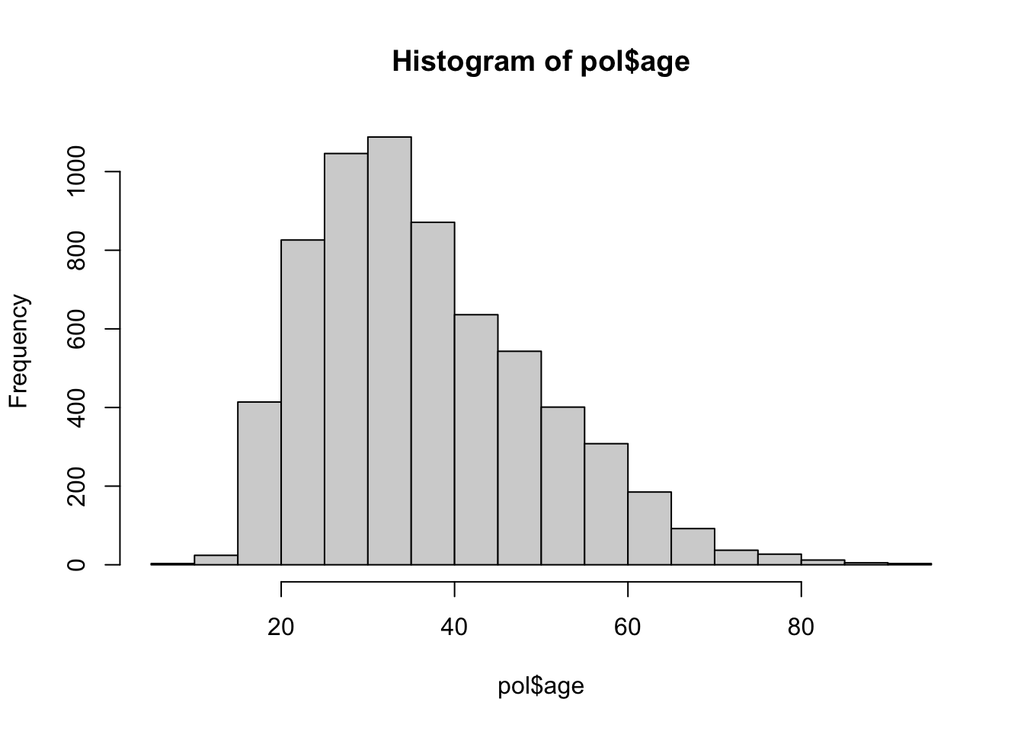

```r
hist(pol$age)
```

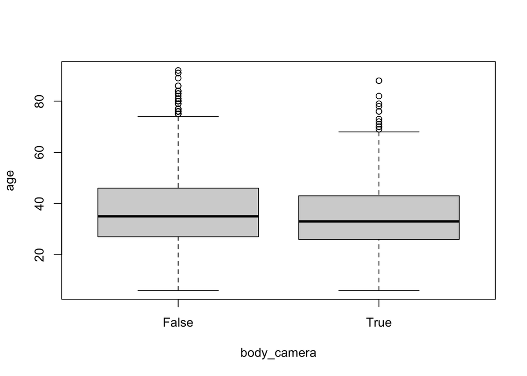

```r
boxplot(age ~ body_camera, data=pol)
```

## Histograrms

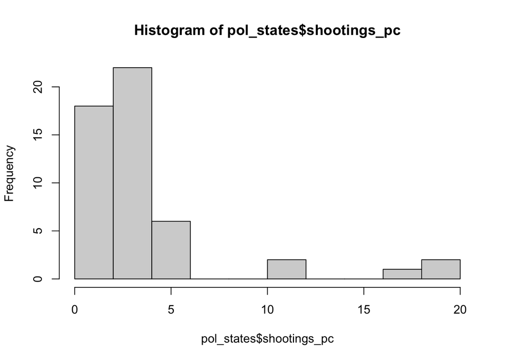

```r
hist(pol_states$shootings_pc)
```

## Boxplots

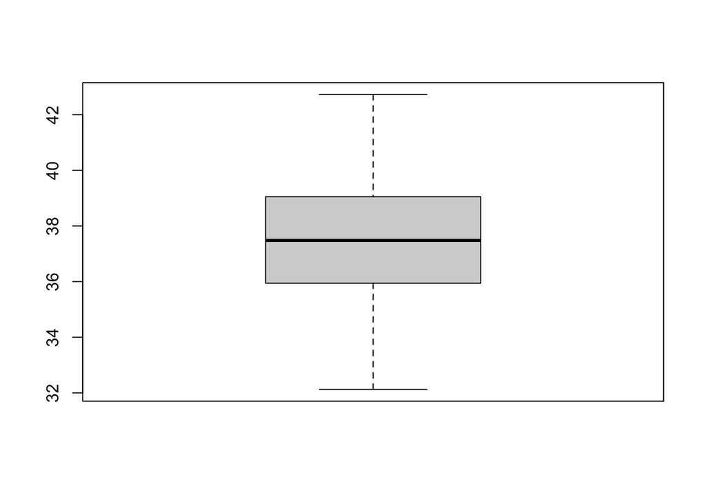

```r
boxplot(pol_states$age)
```

## Boxplots

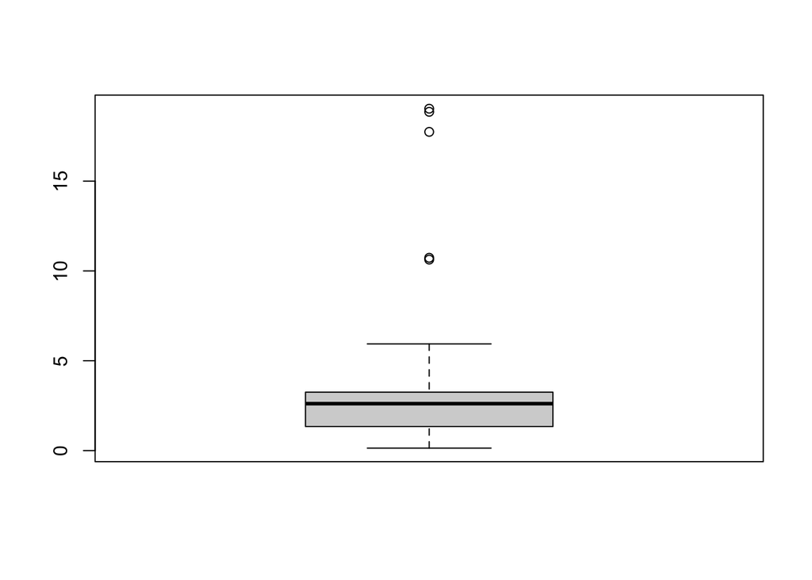

```r
boxplot(pol_states$shootings_pc)
```

## Scatterplots

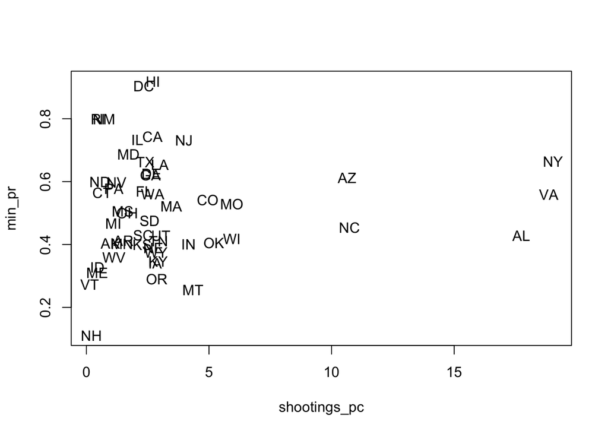

```r
with(pol_states, plot(shootings_pc, min_pr, pch = NA))
with(pol_states, text(shootings_pc, min_pr, state))
```

## Body Cams

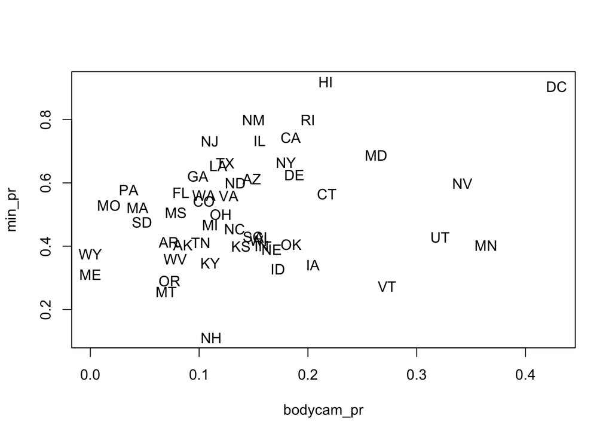

```r
with(pol_states, plot(bodycam_pr, min_pr, pch = NA))
with(pol_states, text(bodycam_pr, min_pr, state))
```